# Desafio Técnico Data Analytics (ESTÁGIO) - Matheus Bastos

Matheus Bastos

01 de maio de 2021

#### Breve introdução

Olá ! Meu nome é Matheus Bastos, sou estudante de Estatística (por amor) da UFAM e realizei este desafio utilizando a linguagem R :)

Durante a construção do código, tentei sempre incluir gráficos que nos ajudam a visualizar os resultados obtidos. Além disso, ao longo de cada etapa, optei por colocar uma breve descrição da análise realizada com o objetivo de deixar o mais claro possível cada etapa realizada.

Estarei à disposição para sanar qualquer dúvida relacionada ao código e às análises :)

Desde já agradeço a oportunidade e de participar desta seleção que têm me agregado bastante conhecimento.

### PARTE 3 DO DESAFIO

#### QUESTÕES 1 E 2: ESTATÍSTICAS BÁSICAS DA COMPRA E COMO OS DADOS ESTÃO DISTRIBUÍDOS AO LONGO DO TEMPO.

A primeira etapa realizada foi a importação das bases de dados para o ambiente do Rstudio.

O arquivo *Dados_vale_credito_tabela1.csv* será definido como **tabela1**.

O arquivo *Dados_vale_credito_tabela2.csv* será definido como **tabela2**.

**IMPORTAÇÃO DOS ARQUIVOS:**

```r
library(readr)

#TABELA 1 - arquivo: "Dados_vale_credito_tabela1.csv"
tabela1 = read_csv("Dados_vale_credito_tabela1.csv") #importação da tabela1
#TABELA 2 - arquivo: "Dados_vale_credito_tabela2.csv"
tabela2 = read.csv("Dados_vale_credito_tabela2.csv")
```

Ao importar as tabelas para o RStudio, podemos visualizar melhor os dados e perceber que a **tabela 1** e a **tabela 2** possuem características distintas.

A **tabela 1** apresenta a descrição do **NIVEL** de cada cliente e seus respectivos **SALDOS**, além de informar a **DATA DE MUDANÇA** de nível dos cliente.

Já a **tabela 2** apresenta os **TIPOS DE TRANSAÇÕES** realizadas pelos clientes, o **VALOR MOVIMENTADO** em cada transação, o **SALDO** após a transação e outras informações como data da operação e a loja em que foi realizada.

Visto que as duas tabelas nos proporcionam uma série de variáveis distintas, optarei por analisar as duas tabelas de forma independente. Assim poderemos extrair o máximo de informação de cada uma delas :)

##### EXPLORANDO OS DADOS DA TABELA 1

###### 1. Distribuição dos níveis - Clientes TABELA 1

Primeiro, iremos analisar a distribuição dos níveis entres os clientes apresentados na TABELA 1:

```r
#Número de clientes de cada nivel
#Criando uma tabela com os distintos níveis de clientes e a frequência de cada.

nivel_clientes = as.data.frame(table(tabela1$DESCRICAO_NIVEL))

nivel_clientes
```

```
##        Var1 Freq
## 1      AZUL   11
## 2  DIAMANTE  297
## 3 DIAMANTE+  448
## 4      OURO  166
## 5     PRATA   78
```

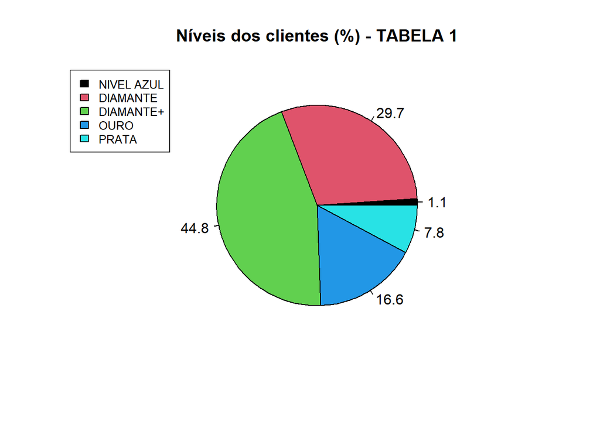

```r
#Cálculo da porcentagem que cada nível representa na TABELA 1:

azul = round((nivel_clientes[1,2]/1000)*100, 2)
diamante = round((nivel_clientes[2,2]/1000)*100, 2)
diamante_mais = round((nivel_clientes[3,2]/1000)*100, 2)
ouro = round((nivel_clientes[4,2]/1000)*100, 2)
prata = round((nivel_clientes[5,2]/1000)*100, 2)

#Colocando os valores em um vetor para a construção do gráfico:

vetor_niveis = c(azul, diamante, diamante_mais, ouro, prata)

#Construção do gráfico:

pie(vetor_niveis, main = "Níveis dos clientes (%) - TABELA 1", labels = vetor_niveis, col = seq(1,5))

legend("topleft", fill = seq(1,5), legend = c("NIVEL AZUL", "DIAMANTE", "DIAMANTE+", "OURO", "PRATA"), cex = 0.8)
```

Percebemos então, na TABELA 1, que **44.8%** dos clientes pertencem ao nível **DIAMANTE+**, **29.7%** ao nível **DIAMANTE**, **16.6%** ao nível **OURO**, **7.8%** ao nível **PRATA** e apenas **1.1%** ao nível **AZUL**.

Portanto, através da TABELA 1 é perceptível que a maior mudança de pedra foi a realizada pelos clientes que chegaram no nível DIAMANTE+, seguidos pelos clientes que chegaram no nível DIAMANTE. Esse crescimento, seguindo a orientação dos níveis, demonstra um processo eficaz de fidelização dos clientes.

###### 2. Análise dos saldos - Clientes TABELA 1

A TABELA 1 também informa o SALDO de cada um dos 1000 clientes. Podemos encontrar o saldo médio entre os clientes da TABELA 1.

```r
media.saldos = round(mean(tabela1$SALDO_VC), 2)
mediana.saldos = round(median(tabela1$SALDO_VC), 2)

cat("O saldo médio dos clientes da TABELA 1 é: R$" , media.saldos , "\n")
```

```
## O saldo médio dos clientes da TABELA 1 é: R$ 21.85
```

```r
cat("A mediana entre saldos é: R$", mediana.saldos)
```

```
## A mediana entre saldos é: R$ 0.98
```

Para este caso, o **saldo médio** de **R$ 21,85** pode ser um valor enganoso, visto que a diferença entre o valor do maior saldo e do menor é proporcionalmente muito grande. Portanto, o cálculo da mediana nos possibilita uma reflexão mais próxima da realidade.

A **mediana** dos saldos tem valor de **R$ 0,98**. Isso significa que aproximadamente METADE dos clientes não possuem um saldo de vale crédito superior à **R$ 1**.

Com o objetivo de encontrar uma análise ainda mais aprofundada dos saldos, podemos calcular individualmente a média e mediana de cada um dos NÍVEIS.

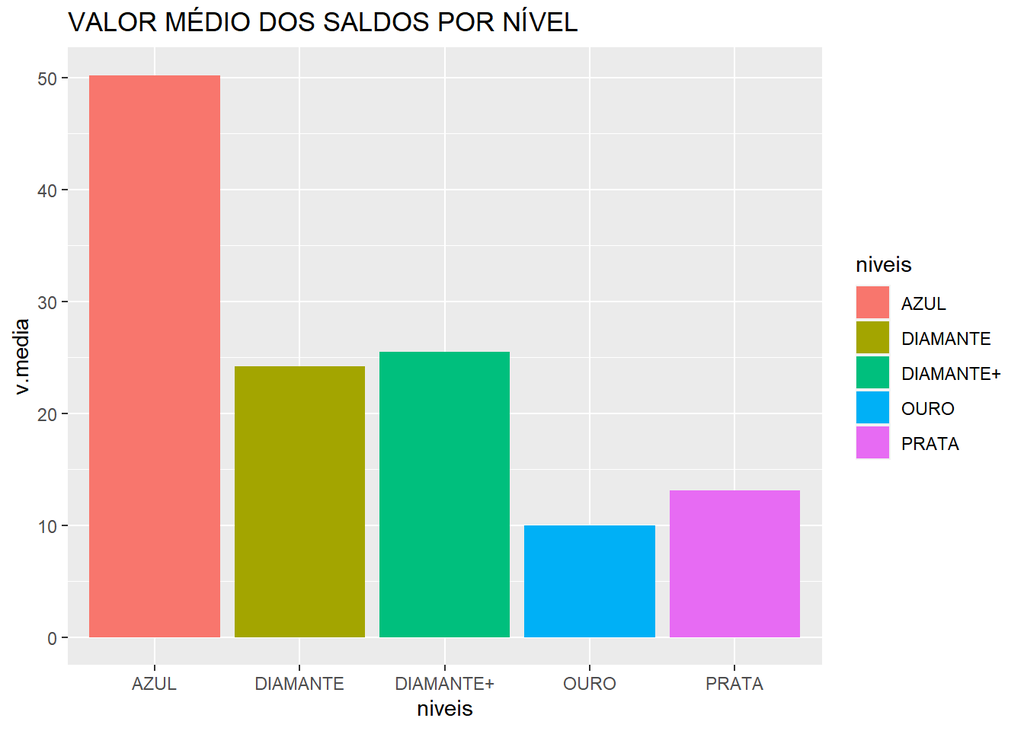

```r
#Media dos saldos de cada nivel
media.diamante.plus = round(mean(tabela1$SALDO_VC[tabela1$DESCRICAO_NIVEL == "DIAMANTE+"]),2)
media.diamante = round(mean(tabela1$SALDO_VC[tabela1$DESCRICAO_NIVEL == "DIAMANTE"]),2)
media.ouro = round(mean(tabela1$SALDO_VC[tabela1$DESCRICAO_NIVEL == "OURO"]),2)
media.prata = round(mean(tabela1$SALDO_VC[tabela1$DESCRICAO_NIVEL == "PRATA"]),2)
media.azul = round(mean(tabela1$SALDO_VC[tabela1$DESCRICAO_NIVEL == "AZUL"]),2)

#Mediana dos saldos de cada nivel
mediana.diamante.plus = round(median(tabela1$SALDO_VC[tabela1$DESCRICAO_NIVEL == "DIAMANTE+"]),2)
mediana.diamante = round(median(tabela1$SALDO_VC[tabela1$DESCRICAO_NIVEL == "DIAMANTE"]),2)
mediana.ouro = round(median(tabela1$SALDO_VC[tabela1$DESCRICAO_NIVEL == "OURO"]),2)
mediana.prata = round(median(tabela1$SALDO_VC[tabela1$DESCRICAO_NIVEL == "PRATA"]),2)
mediana.azul = round(median(tabela1$SALDO_VC[tabela1$DESCRICAO_NIVEL == "AZUL"]),2)

#Vetores com os resultados
v.media = c(media.diamante.plus, media.diamante, media.ouro, media.prata, media.azul)
v.mediana = c(mediana.diamante.plus, mediana.diamante, mediana.ouro, mediana.prata, mediana.azul)

#GRÁFICO PARA AS MÉDIAS
library(ggplot2)

niveis = c("DIAMANTE+", "DIAMANTE", "OURO", "PRATA", "AZUL")

df.medias = data.frame(niveis, v.media)

ggplot(df.medias, aes(y = v.media, x = niveis, fill = niveis)) +
  geom_bar(stat = "identity") +
  geom_col() +
  labs(title = "VALOR MÉDIO DOS SALDOS POR NÍVEL")
```

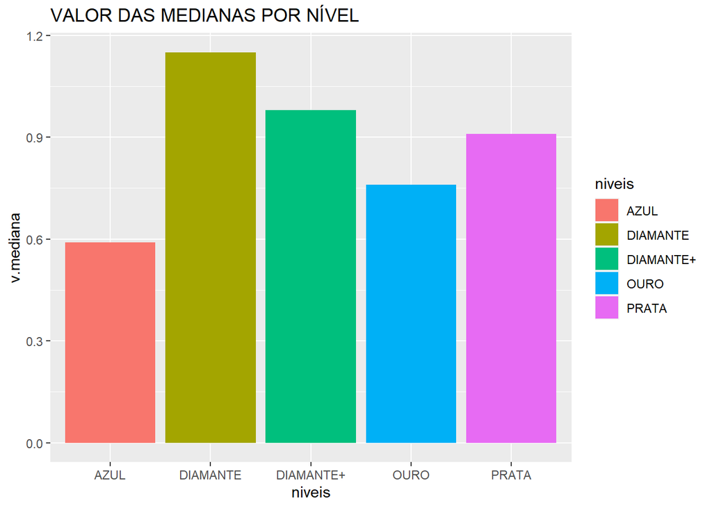

```r
#GRÁFICO PARA AS MEDIANAS

df.medianas = data.frame(niveis, v.mediana)

ggplot(df.medianas, aes(y = v.mediana, x = niveis, fill = niveis)) +
  geom_bar(stat = "identity") +
  geom_col() +
  labs(title = "VALOR DAS MEDIANAS POR NÍVEL")
```

O resultado que obtemos demonstra que o **MAIOR saldo médio**, entre os níveis, é o saldo médio dos clientes de nível **AZUL** que possuem um saldo médio de aproximadamente **R$ 50,21**. Mas a mediana desse nível, demonstra que pelo menos 50% dos clientes não chegam ao saldo de **R$ 0,60**.

Diferentemente dos clientes do nível **DIAMANTE**, que possuem um saldo médio de **R$ 24,22**, mas que através da mediana, demonstra que metade dos clientes nesse nível, possuem o **dobro** do saldo dos clientes no nível **AZUL**.

###### 3. Datas de mudança de pedra - Clientes TABELA 1

Outra variável da TABELA 1 são as DATAS de Mudança das pedras. Todas as datas são referentes ao ano de 2020. Portanto, farei a análise das mudanças de pedra ao longo dos meses de 2020.

```r
#DATAS NA TABELA 1

library(lubridate)
class(tabela1$DT_MUDANCA_PEDRA)
```

```
## [1] "Date"
```

```r
#Anos das mudanças listadas na tabela:

table(year(tabela1$DT_MUDANCA_PEDRA))
```

```
##
## 2020
## 1000
```

```r
#Percebe-se que todas as mudanças são de 2020, distribuídas nos meses de MAIO, JUNHO E JULHO.

#Quantidade de mudanças por mês

meses = table(months.Date(tabela1$DT_MUDANCA_PEDRA))
meses
```

```
##
## julho junho  maio
##    38   665   297
```

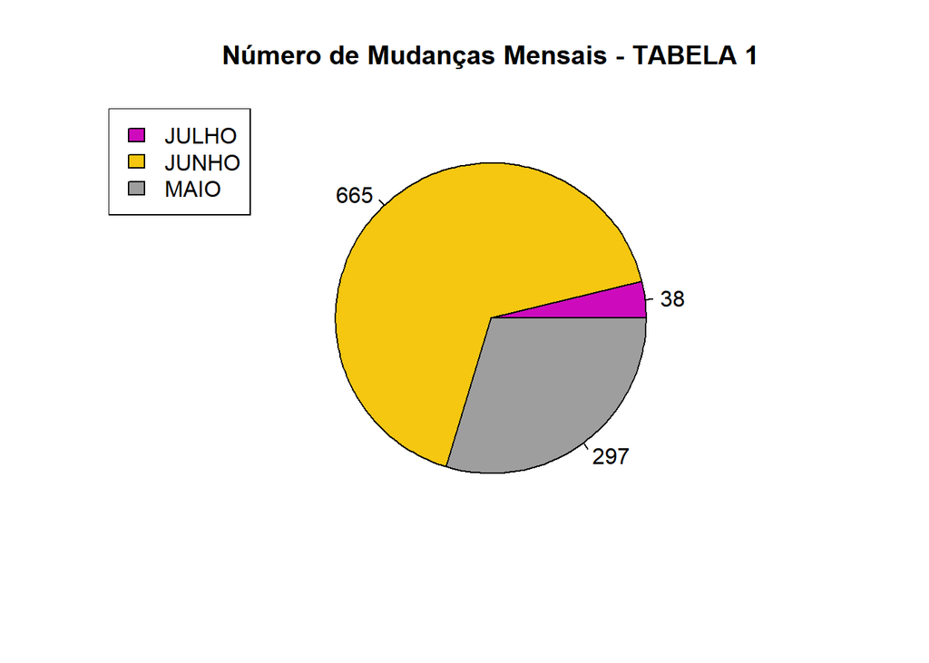

```r
#Gráfico do número de mudanças em 2020

pie(meses, main = "Número de Mudanças Mensais - TABELA 1", labels = meses, col = seq(6,9))
legend("topleft", fill = seq(6,9), legend = c("JULHO", "JUNHO", "MAIO"), cex = 1)
```

A tabela nos proporciona apenas o cenário de 3 meses de operações de mudança de pedra. Tendo a maior concentração no mês de JUNHO.

##### EXPLORANDO OS DADOS DA TABELA 2

###### 1. Análise dos clientes - TABELA 2:

```r
#Analisando os clientes da TABELA 2

#Utilizando a função table, veremos quantos clientes distintos temos na tabela e a respectiva frequencia de operações realizadas por cada um.

cliente2 = table(tabela2$CLIENTE)

#Encontrando o maior número de operações realizadas por um único cliente:

cliente2[which.max(cliente2)]
```

```
## 1245390
##      54
```

Com a operação, encontramos o cliente com o maior número de operações realizadas ao longo dos registros da TABELA 2. O cliente **1245390** realizou ao todo, **54** operações.

Além disso, encontrar a frequência de operações realizadas pelos clientes nos permite identificar o perfil de compra de cada cliente.

###### 2. Análise de DÉBITOS e CRÉDITOS - TABELA 2

Uma das variáveis apresentada na TABELA 2 é de **DÉBITOS E CRÉDITOS**, descrita na coluna **DEBITO_OU_CREDITO**. Analisaremos qual a tendência desses fatores (Débito ou Crédito) nas operações listadas na tabela.

É importante destacar a função dessas duas variáveis.

A variável *DÉBITO* retira o valor X do saldo. Enquanto a variável *CRÉDITO* acrescenta o valor X ao saldo do cliente que realizou a operação.

```r
#transformar as opções em uma tabela - identificar a frequencia de cada

debito_credito = table(tabela2$DEBITO_OU_CREDITO)
debito_credito
```

```
##
## CREDITO  DEBITO
##  268698  111626
```

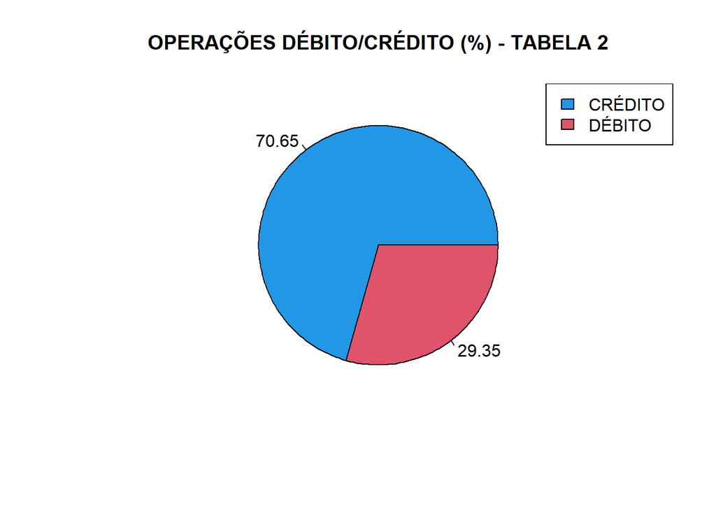

```r
#total de operações realizadas
total.de.operacoes = sum(debito_credito)

#calculo da porcentagem das opções DÉBITO E CRÉDITO
credito = round((debito_credito[1]/total.de.operacoes)*100, 2)

debito = round((debito_credito[2]/total.de.operacoes)*100, 2)

#Construção do Gráfico

v.debito_credito = c(credito, debito)

pie(v.debito_credito, main = "OPERAÇÕES DÉBITO/CRÉDITO (%) - TABELA 2" , labels = v.debito_credito, col = c(4,2))
legend("topright", fill = c(4,2), legend = c("CRÉDITO", "DÉBITO"))
```

###### 3. Análise dos Tipos de Transações - TABELA 2

Um dos elementos que constam na TABELA 2 são os tipos de transações realizadas pelos cliente. Farei uma análise dessas operações para identificar a preferência dos clientes.

O primeiro passo é identificar quais são os tipos de transações e as respectivas frequências com as quais eles aparecem na TABELA 2.

```r
#Criando o data frame com as operações e frequências
tipos.de.transacoes = as.data.frame(table(tabela2$TIPO_TRANSACAO_VC))

#trocando os nomes das colunas
colnames(tipos.de.transacoes)[1] = "TRANSACAO"
colnames(tipos.de.transacoes)[2] = "FREQUENCIA"
```

Descobrimos então que a tabela possui 21 tipos distintos de transações. Com isso, podemos analisar a representação percentual de cada uma dessas transações na TABELA 2.

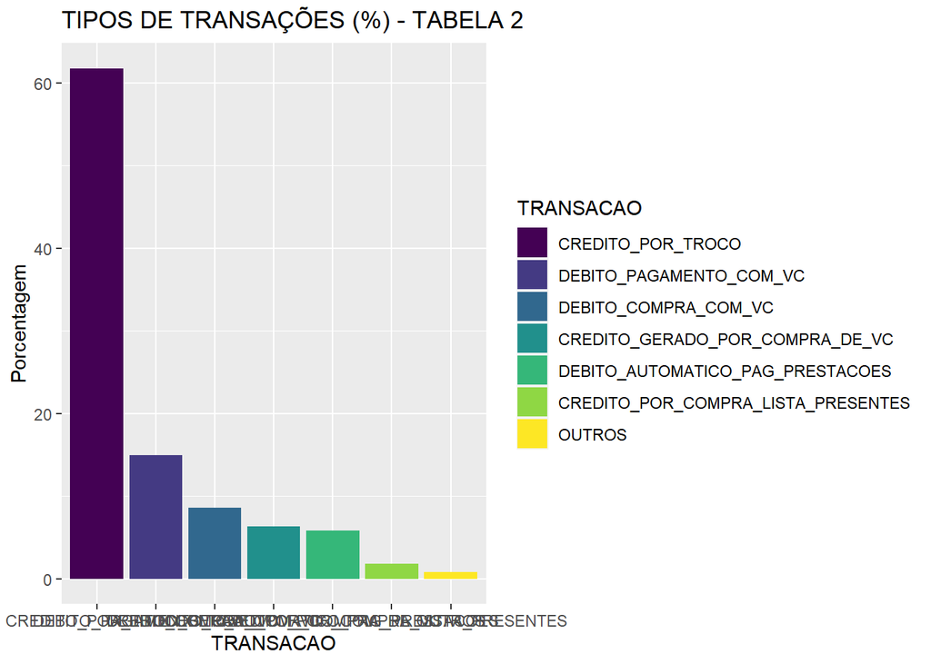

```r
#Cálculo das porcentagens dos tipos de Transação da TABELA 2
# Há um acréscimo de 2 novos tipos de transação: debito.duplicidade e doacoes

ajuste.contabil.2 = round((tipos.de.transacoes[1,2]/total.de.operacoes)*100 , 2)
lancamento.incorreto.2 = round((tipos.de.transacoes[2,2]/total.de.operacoes)*100, 2)
credito.conversao.2 = round((tipos.de.transacoes[3,2]/total.de.operacoes)*100, 2)
credito.gerado.devo.2 = round((tipos.de.transacoes[4,2]/total.de.operacoes)*100, 2)
credito.gerado.compra.2 = round((tipos.de.transacoes[5,2]/total.de.operacoes)*100, 2)
credito.compra.lista.2 = round((tipos.de.transacoes[6,2]/total.de.operacoes)*100, 2)
credito.troco.2 = round((tipos.de.transacoes[7,2]/total.de.operacoes)*100, 2)
credito.premiacao.2 = round((tipos.de.transacoes[8,2]/total.de.operacoes)*100, 2)
credito.premiacao.gerenci.2 = round((tipos.de.transacoes[9,2]/total.de.operacoes)*100, 2)
debito.automatico.2 = round((tipos.de.transacoes[10,2]/total.de.operacoes)*100, 2)
debito.compra.2 = round((tipos.de.transacoes[11,2]/total.de.operacoes)*100, 2)
debito.devolucao.compra.2 = round((tipos.de.transacoes[12,2]/total.de.operacoes)*100, 2)
debito.devolucao.compra.vc.2 = round((tipos.de.transacoes[13,2]/total.de.operacoes)*100, 2)
debito.duplicidade = round((tipos.de.transacoes[14,2]/total.de.operacoes)*100, 2)
debito.estorno.pres.2 = round((tipos.de.transacoes[15,2]/total.de.operacoes)*100, 2)
debito.estorno.troco.2 = round((tipos.de.transacoes[16,2]/total.de.operacoes)*100, 2)
debito.pagamento.vc.2 = round((tipos.de.transacoes[17,2]/total.de.operacoes)*100, 2)
debito.por.estorno.2 = round((tipos.de.transacoes[18,2]/total.de.operacoes)*100, 2)
doacoes = round((tipos.de.transacoes[19,2]/total.de.operacoes)*100, 2)
transferencia.clientes.2 = round((tipos.de.transacoes[20,2]/total.de.operacoes)*100, 2)
transferencia.whasapp.2 = round((tipos.de.transacoes[21,2]/total.de.operacoes)*100, 2)

# Reunindo as porcentagens em um único vetor

transacoes = c(ajuste.contabil.2, lancamento.incorreto.2, credito.conversao.2, credito.gerado.devo.2, credito.gerado.compra.2, credito.compra.lista.2, credito.troco.2, credito.premiacao.2, credito.premiacao.gerenci.2, debito.automatico.2, debito.compra.2, debito.devolucao.compra.2, debito.devolucao.compra.vc.2,debito.duplicidade, debito.estorno.pres.2, debito.estorno.troco.2, debito.pagamento.vc.2, debito.por.estorno.2, doacoes, transferencia.clientes.2, transferencia.whasapp.2)

# Incluindo o vetor de Porcentagem no Data Frame dos Tipos de Transação

tipos.de.transacoes$Porcentagem = transacoes

# Nota-se a mesma proporção da TABELA 1: Aproximadamente 99% das operações concentra-se em apenas 6 tipos de transação

# Valores maiores que 1%

im = which(tipos.de.transacoes$Porcentagem > 1)
maiores.transacoes = tipos.de.transacoes[im, ] #Tais valores são os mais recorrentes.

#valores menores ou iguais a 1%

ie = which(tipos.de.transacoes$Porcentagem <= 1)
menores.transacoes = tipos.de.transacoes[ie, ]

freq.menores = sum(menores.transacoes$FREQUENCIA)
porcent.menores = sum(menores.transacoes$Porcentagem) #Representam apenas 1% do total

#Acrescentando as informações da menor parte no data frame que mostrará o gráfico

linha = data.frame(TRANSACAO = "OUTROS" , FREQUENCIA = freq.menores, Porcentagem = porcent.menores)

maiores.transacoes = rbind(maiores.transacoes, linha)

#Construção do gráfico proporcional para os tipos de Transações da TABELA 2

library(ggplot2)

idx = order(maiores.transacoes$Porcentagem, decreasing = TRUE)

levels = maiores.transacoes$TRANSACAO[idx]

maiores.transacoes$TRANSACAO = factor(maiores.transacoes$TRANSACAO, levels=levels, ordered=TRUE)

ggplot(maiores.transacoes, aes(x = TRANSACAO, y = Porcentagem, fill = TRANSACAO)) +
  geom_col() +
  labs(title = "TIPOS DE TRANSAÇÕES (%) - TABELA 2")
```

Com o gráfico, ficou visualmente fácil de notar que a transação *CREDITO POR TROCO* foi a mais utilizada dentre as operações registradas na TABELA 2.

A transação representa **61,76%** do total de operações realizadas. A possível justificativa para essa margem tão grande é a facilidade da sua realização ao final de toda compra, tendo uma grande adesão por parte dos clientes.

A tabela a seguir apresenta a demonstração percentual de todos os tipos de transações:

```r
library(formattable)

formattable::formattable(maiores.transacoes, caption = "Porcentagem das opções de transação")
```

Porcentagem das opções de transação

|  | TRANSACAO | FREQUENCIA | Porcentagem |
| --- | --- | --- | --- |
| 5 | CREDITO_GERADO_POR_COMPRA_DE_VC | 24056 | 6.33 |
| 6 | CREDITO_POR_COMPRA_LISTA_PRESENTES | 6803 | 1.79 |
| 7 | CREDITO_POR_TROCO | 234875 | 61.76 |
| 10 | DEBITO_AUTOMATICO_PAG_PRESTACOES | 22119 | 5.82 |
| 11 | DEBITO_COMPRA_COM_VC | 32591 | 8.57 |
| 17 | DEBITO_PAGAMENTO_COM_VC | 56800 | 14.93 |
| 1 | OUTROS | 3080 | 0.79 |

###### 4. Análise das transações ao longo dos anos - TABELA 2

O objetivo dessa análise é observar o crescimento (ou diminuição) das operações registradas em cada ano.

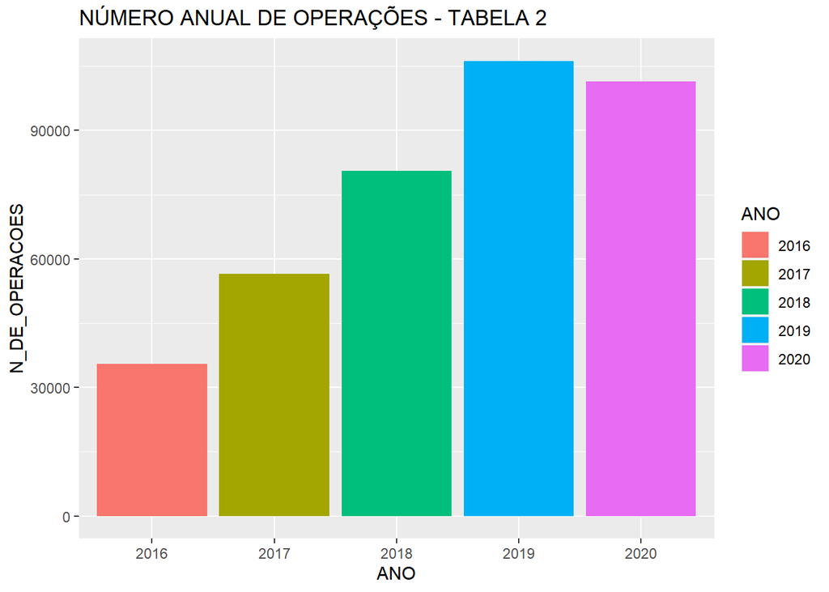

```r
#TRABALHANDO COM TEMPO
library(lubridate)

#Transformando a classe para DATE
tabela2$DATA_DA_MOVIMENTACAO = as.Date(tabela2$DATA_DA_MOVIMENTACAO)

#QUANTIDADE DE MOVIMENTAÇÕES ANUAIS

#Criando um tabela com o numero de operações de cada ano
ano = as.data.frame(table(year(tabela2$DATA_DA_MOVIMENTACAO)))
colnames(ano)[1] = "ANO"
colnames(ano)[2] = "N_DE_OPERACOES"

#Gráfico em barras DA QUANTIDADE DE MOVIMENTAÇÕES ANUAIS

library(ggplot2)

idxt2 = order(ano$ANO, decreasing = F)

levels = ano$ANO[idxt2]

ano$ANO = factor(ano$ANO, levels=levels, ordered= F)

ggplot(ano, aes(x = ANO, y = N_DE_OPERACOES, fill = ANO)) +
  geom_col() +
  labs(title = "NÚMERO ANUAL DE OPERAÇÕES - TABELA 2")
```

O gráfico apresenta um notório crescimento do número de operações realizadas ao longo dos anos.Apesar do crescimento nos anos de 2017, 2018 e 2019, é possível observar uma leva queda em 2020 em relação ao ano anterior.

Por conta disso, faremos uma análise do percentual de crescimento anual.

```r
# Crescimento percentual em relação ao ano anterior
crescimento17 = round(((ano[2,2] - ano[1,2]) / ano[1,2])*100, 2)
crescimento18 = round(((ano[3,2] - ano[2,2]) / ano[2,2])*100, 2)
crescimento19 = round(((ano[4,2] - ano[3,2]) / ano[3,2])*100, 2)
crescimento20 = round(((ano[5,2] - ano[4,2]) / ano[4,2])*100, 2)

# agrupando em um vetor
v.cresc = c(crescimento17, crescimento18, crescimento19, crescimento20)

# resultado
cat("O crescimento médio anual, do número de operações, é:" ,mean(v.cresc), "%")
```

```
## O crescimento médio anual, do número de operações, é: 32.24 %
```

A TABELA 2 apresenta um expressivo crescimento médio nas operações ao longo dos anos. O crescimento médio anual chega à expressiva taxa de **32.24 %**. O único ano que apresenta redução neste crescimento é o de 2020 com uma *queda* de **-4.5%** no número de operações.

Uma possível justificativa para essa redução em 2020 é o enfrentamento da pandemia de COVID-19 que ocasionou diversas restrições comerciais.

Além disso, podemos analisar a distribuição das operações ao longo dos meses do ano com o objetivo de identificar os meses com maior e menor fluxo de operações.

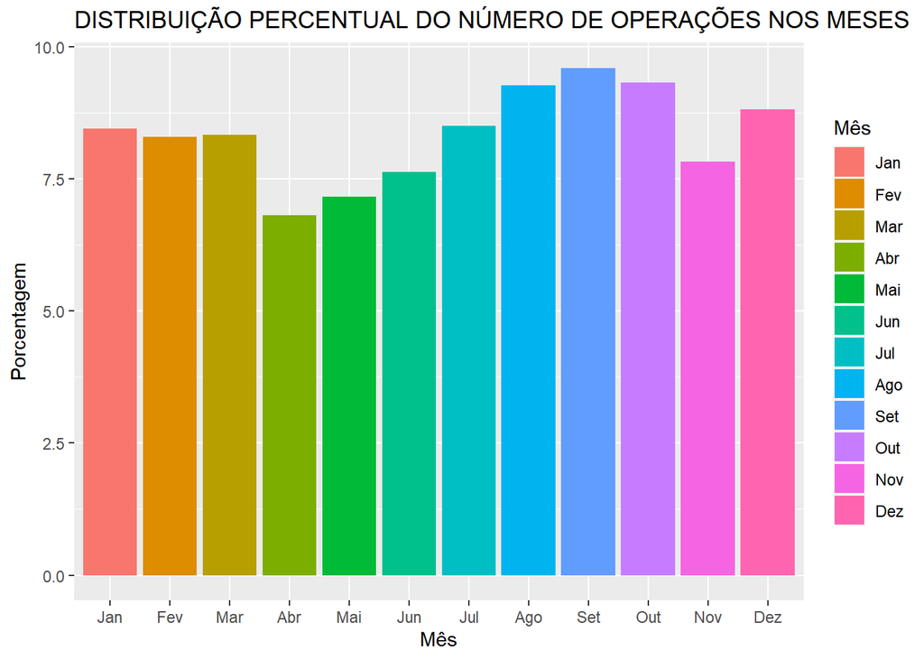

```r
#Meses das movimentações
meses2 = table(month(tabela2$DATA_DA_MOVIMENTACAO))

#Porcentagem do número de operações em cada mês
jan = round((meses2[1]/total.de.operacoes)*100, 2)
fev = round((meses2[2]/total.de.operacoes)*100, 2)
mar = round((meses2[3]/total.de.operacoes)*100, 2)
abr = round((meses2[4]/total.de.operacoes)*100, 2)
mai = round((meses2[5]/total.de.operacoes)*100, 2)
jun = round((meses2[6]/total.de.operacoes)*100, 2)
jul = round((meses2[7]/total.de.operacoes)*100, 2)
ago = round((meses2[8]/total.de.operacoes)*100, 2)
set = round((meses2[9]/total.de.operacoes)*100, 2)
out = round((meses2[10]/total.de.operacoes)*100, 2)
nov = round((meses2[11]/total.de.operacoes)*100, 2)
dez = round((meses2[12]/total.de.operacoes)*100, 2)

#Vetores para o Gráfico
v2_meses = c(jan, fev, mar, abr, mai, jun, jul, ago, set, out, nov, dez)
v2_nomes = c("Jan", "Fev", "Mar", "Abr", "Mai", "Jun", "Jul", "Ago", "Set", "Out", "Nov", "Dez")

#Data frame que irá gerar o gráfico
v2_meses = as.data.frame(v2_meses)
v2_meses = cbind(v2_meses, v2_nomes)

colnames(v2_meses)[1] = "Porcentagem"
colnames(v2_meses)[2] = "Mês"

#Construção do gráfico de barras
library(ggplot2)

v2_meses$Mês = factor(v2_meses$Mês, levels = v2_meses$Mês, ordered= F)

ggplot(v2_meses, aes(x = Mês, y = Porcentagem, fill = Mês)) +
  geom_col() +
  labs(title = "DISTRIBUIÇÃO PERCENTUAL DO NÚMERO DE OPERAÇÕES NOS MESES")
```

O gráfico demonstra a distribuição mensal das opeções. É perceptível que o mês de **ABRIL** possui o menor número de operações resgistradas, tendo uma recuperação a partir do mês de **JULHO**.

Os meses de **agosto, setembro e outubro**, possuem, percentualmente, o maior número de operações realizadas em relação aos demais meses. Além disso, percebemos uma regularidade entre os meses de **dezembro, janeiro, fevereiro e março**.

###### 5. Análise individual dos tipos de operações - TABELA 2

Esta análise tem objetivo de dimensionar, individualmente, as operações realizadas em cada ano.

Poderemos, ao final da análise, identificar quais os tipos de transações foram mais utilizados nos anos descritos e também realizar uma análise focada em 2020.

Começaremos descrevendo a frequência de cada operação entre os anos de 2016 e 2020.

```r
#criando o data frame (ANO | TIPO DE TRANSAÇÃO)

transacao.ano= as.data.frame(format(tabela2$DATA_DA_MOVIMENTACAO , "%Y"))
transacao.ano = cbind(transacao.ano , tabela2$TIPO_TRANSACAO_VC)

colnames(transacao.ano)[1] = "anos"
colnames(transacao.ano)[2] = "transação"

# TABELA EM QUE SERÁ ACRESCENTADA AS INFORMAÇÕES
operacoes.individuais = as.data.frame(table(year(tabela2$DATA_DA_MOVIMENTACAO)))
colnames(operacoes.individuais)[1] = "ANO"
colnames(operacoes.individuais)[2] = "TOTAL DE OPERAÇÕES"

#CREDITO_POR_TROCO

num.trsc.2020.cred = sum(transacao.ano$anos == "2020" & transacao.ano$transação == "CREDITO_POR_TROCO")
num.trsc.2019.cred = sum(transacao.ano$anos == "2019" & transacao.ano$transação == "CREDITO_POR_TROCO")
num.trsc.2018.cred = sum(transacao.ano$anos == "2018" & transacao.ano$transação == "CREDITO_POR_TROCO")
num.trsc.2017.cred = sum(transacao.ano$anos == "2017" & transacao.ano$transação == "CREDITO_POR_TROCO")
num.trsc.2016.cred = sum(transacao.ano$anos == "2016" & transacao.ano$transação == "CREDITO_POR_TROCO")

repeticoes.cred.troco= c(num.trsc.2016.cred, num.trsc.2017.cred, num.trsc.2018.cred, num.trsc.2019.cred, num.trsc.2020.cred)

operacoes.individuais$CREDITO_POR_TROCO = repeticoes.cred.troco

prct.cred.troco = round(((operacoes.individuais[5,3] - operacoes.individuais[4,3])/operacoes.individuais[4,3])*100, 2) #crescimento/queda percentual em relação ao ano anterior

#DEBITO_PAGAMENTO_COM_VC

num.trsc.2020.deb.pg = sum(transacao.ano$anos == "2020" & transacao.ano$transação == "DEBITO_PAGAMENTO_COM_VC")
num.trsc.2019.deb.pg = sum(transacao.ano$anos == "2019" & transacao.ano$transação == "DEBITO_PAGAMENTO_COM_VC")
num.trsc.2018.deb.pg = sum(transacao.ano$anos == "2018" & transacao.ano$transação == "DEBITO_PAGAMENTO_COM_VC")
num.trsc.2017.deb.pg = sum(transacao.ano$anos == "2017" & transacao.ano$transação == "DEBITO_PAGAMENTO_COM_VC")
num.trsc.2016.deb.pg = sum(transacao.ano$anos == "2016" & transacao.ano$transação == "DEBITO_PAGAMENTO_COM_VC")

repeticoes.deb.pg= c(num.trsc.2016.deb.pg, num.trsc.2017.deb.pg, num.trsc.2018.deb.pg, num.trsc.2019.deb.pg, num.trsc.2020.deb.pg)

operacoes.individuais$DEBITO_PAGAMENTO_COM_VC = repeticoes.deb.pg

prct.deb.pg = round(((operacoes.individuais[5,4] - operacoes.individuais[4,4])/operacoes.individuais[4,4])*100, 2) #crescimento/queda percentual em relação ao ano anterior

#DEBITO_COMPRA_COM_VC

num.trsc.2020 = sum(transacao.ano$anos == "2020" & transacao.ano$transação == "DEBITO_COMPRA_COM_VC")
num.trsc.2019 = sum(transacao.ano$anos == "2019" & transacao.ano$transação == "DEBITO_COMPRA_COM_VC")
num.trsc.2018 = sum(transacao.ano$anos == "2018" & transacao.ano$transação == "DEBITO_COMPRA_COM_VC")
num.trsc.2017 = sum(transacao.ano$anos == "2017" & transacao.ano$transação == "DEBITO_COMPRA_COM_VC")
num.trsc.2016 = sum(transacao.ano$anos == "2016" & transacao.ano$transação == "DEBITO_COMPRA_COM_VC")

repeticoes.debito.vc = c(num.trsc.2016, num.trsc.2017, num.trsc.2018, num.trsc.2019, num.trsc.2020)

operacoes.individuais$DEBITO_COMPRA_COM_vc = repeticoes.debito.vc

prct.debito.vc = round(((operacoes.individuais[5,5] - operacoes.individuais[4,5])/operacoes.individuais[4,5])*100 ,2) #crescimento/queda percentual em relação ao ano anterior

#CREDITO_GERADO_POR_COMPRA_DE_VC

num.trsc.2020.cred.ger = sum(transacao.ano$anos == "2020" & transacao.ano$transação == "CREDITO_GERADO_POR_COMPRA_DE_VC")
num.trsc.2019.cred.ger = sum(transacao.ano$anos == "2019" & transacao.ano$transação == "CREDITO_GERADO_POR_COMPRA_DE_VC")
num.trsc.2018.cred.ger = sum(transacao.ano$anos == "2018" & transacao.ano$transação == "CREDITO_GERADO_POR_COMPRA_DE_VC")
num.trsc.2017.cred.ger = sum(transacao.ano$anos == "2017" & transacao.ano$transação == "CREDITO_GERADO_POR_COMPRA_DE_VC")
num.trsc.2016.cred.ger = sum(transacao.ano$anos == "2016" & transacao.ano$transação == "CREDITO_GERADO_POR_COMPRA_DE_VC")

repeticoes.cred.ger= c(num.trsc.2016.cred.ger, num.trsc.2017.cred.ger, num.trsc.2018.cred.ger, num.trsc.2019.cred.ger, num.trsc.2020.cred.ger)

operacoes.individuais$CREDITO_GERADO_POR_COMPRA_DE_VC = repeticoes.cred.ger

prct.cred.ger = round(((operacoes.individuais[5,6] - operacoes.individuais[4,6])/operacoes.individuais[4,6])*100, 2)#crescimento/queda percentual em relação ao ano anterior

#DEBITO_AUTOMATICO_PAG_PRESTACOES

num.transa.2020.deb.auto = sum(transacao.ano$anos == "2020" & transacao.ano$transação == "DEBITO_AUTOMATICO_PAG_PRESTACOES")
num.transa.2019.deb.auto = sum(transacao.ano$anos == "2019" & transacao.ano$transação == "DEBITO_AUTOMATICO_PAG_PRESTACOES")
num.transa.2018.deb.auto = sum(transacao.ano$anos == "2018" & transacao.ano$transação == "DEBITO_AUTOMATICO_PAG_PRESTACOES")
num.transa.2017.deb.auto = sum(transacao.ano$anos == "2017" & transacao.ano$transação == "DEBITO_AUTOMATICO_PAG_PRESTACOES")
num.transa.2016.deb.auto = sum(transacao.ano$anos == "2016" & transacao.ano$transação == "DEBITO_AUTOMATICO_PAG_PRESTACOES")

repeticoes.deb.auto = c(num.transa.2016.deb.auto, num.transa.2017.deb.auto, num.transa.2018.deb.auto, num.transa.2019.deb.auto, num.transa.2020.deb.auto)

operacoes.individuais$DEBITO_AUTOMATICO_PAG_PRESTACOES = repeticoes.deb.auto

prct.deb.auto = round(((operacoes.individuais[5,7] - operacoes.individuais[4,7])/operacoes.individuais[4,7])*100 ,2) #crescimento/queda percentual em relação ao ano anterior

#CREDITO_POR_COMPRA_LISTA_PRESENTES

num.transa.2020.cred.lista = sum(transacao.ano$anos == "2020" & transacao.ano$transação == "CREDITO_POR_COMPRA_LISTA_PRESENTES")
num.transa.2019.cred.lista = sum(transacao.ano$anos == "2019" & transacao.ano$transação == "CREDITO_POR_COMPRA_LISTA_PRESENTES")
num.transa.2018.cred.lista = sum(transacao.ano$anos == "2018" & transacao.ano$transação == "CREDITO_POR_COMPRA_LISTA_PRESENTES")
num.transa.2017.cred.lista = sum(transacao.ano$anos == "2017" & transacao.ano$transação == "CREDITO_POR_COMPRA_LISTA_PRESENTES")
num.transa.2016.cred.lista = sum(transacao.ano$anos == "2016" & transacao.ano$transação == "CREDITO_POR_COMPRA_LISTA_PRESENTES")

repeticoes.cred.lista = c(num.transa.2016.cred.lista, num.transa.2017.cred.lista, num.transa.2018.cred.lista, num.transa.2019.cred.lista, num.transa.2020.cred.lista)

operacoes.individuais$CREDITO_POR_COMPRA_LISTA_PRESENTES = repeticoes.cred.lista

prct.cred.lista = round(((operacoes.individuais[5,8] - operacoes.individuais[4,8])/operacoes.individuais[4,8])*100 , 2) #crescimento/queda percentual em relação ao ano anterior

#criando um vetor com os ganhos/perdas percentuais

prct.tipos.2020 = c(prct.cred.troco, prct.deb.pg, prct.debito.vc, prct.cred.ger, prct.deb.auto, prct.cred.lista)

#TABELA DESCRITIVA COM A QUANTIDADE DE CADA TIPO DE TRANSAÇÃO POR ANO

library(formattable)

formattable::formattable(operacoes.individuais, caption = "Tabela de frequência das operações anuais")
```

Tabela de frequência das operações anuais

| ANO | TOTAL DE OPERAÇÕES | CREDITO_POR_TROCO | DEBITO_PAGAMENTO_COM_VC | DEBITO_COMPRA_COM_vc | CREDITO_GERADO_POR_COMPRA_DE_VC | DEBITO_AUTOMATICO_PAG_PRESTACOES | CREDITO_POR_COMPRA_LISTA_PRESENTES |
| --- | --- | --- | --- | --- | --- | --- | --- |
| 2016 | 35537 | 28149 | 4032 | 1782 | 0 | 0 | 1519 |
| 2017 | 56581 | 41780 | 8500 | 4538 | 0 | 0 | 1668 |
| 2018 | 80527 | 56475 | 14325 | 8019 | 0 | 0 | 1511 |
| 2019 | 106230 | 60543 | 18134 | 9485 | 11592 | 3781 | 1463 |
| 2020 | 101449 | 47928 | 11809 | 8767 | 12464 | 18338 | 642 |

A tabela detalha a quantidade de operações realizadas em cada ano.

A partir desta tabela, realizaremos uma análise focada no ano de **2020** , com o objetivo de encontrar quais operações foram mais realizadas no último ano.

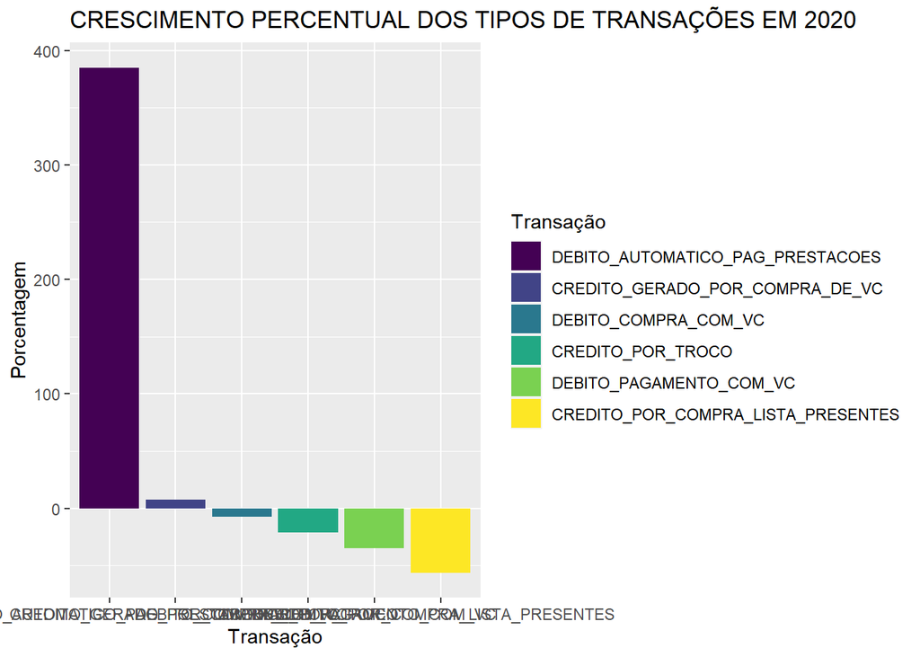

```r
# NOMES DAS TRANSAÇÕES

nomes.transacoes = c("CREDITO_POR_TROCO", "DEBITO_PAGAMENTO_COM_VC", "DEBITO_COMPRA_COM_VC", "CREDITO_GERADO_POR_COMPRA_DE_VC", "DEBITO_AUTOMATICO_PAG_PRESTACOES", "CREDITO_POR_COMPRA_LISTA_PRESENTES")

# GRÁFICO DO CRESCIMENTO/QUEDA DOS TIPOS DE TRANSAÇÕES EM 2020

tipos.prct = as.data.frame(nomes.transacoes)
tipos.prct = cbind(tipos.prct, prct.tipos.2020)

colnames(tipos.prct)[1] = "Transação"
colnames(tipos.prct)[2] = "Porcentagem"

library(ggplot2)

itt = order(tipos.prct$Porcentagem, decreasing = TRUE)

levels = tipos.prct$Transação[itt]

tipos.prct$Transação = factor(tipos.prct$Transação, levels=levels, ordered=TRUE)

ggplot(tipos.prct, aes(x = Transação, y = Porcentagem, fill = Transação)) +
  geom_col() +
  labs(title = "CRESCIMENTO PERCENTUAL DOS TIPOS DE TRANSAÇÕES EM 2020")
```

O gráfico apresenta um aumento percentual, em 2020, de aproximadamente **400%** na transação de **DEBITO_AUTOMATICO_PAG_PRESTACOES** . Um dos possíveis fatores para este crescimento é a facilidade de optar por esse tipo de transação através de aplicativos bancários e o aumento da adesão ao mercado digital.

Outro ponto notório no gráfico é a expressiva queda do tipo de transação **CREDITO_POR_COMPRA_LISTA_PRESENTE**, mais uma vez, a possível justificativa para essa **queda** em 2020 é devida a Pandemia, que impossibilitou a realização de diversos eventos e festas,o que consequentemente causou diminuição das operações envolvendo essa transação.

###### 6. TICKET MÉDIO - TABELA 2

A coluna *VALOR MOVIMENTADO* da TABELA 2 apresenta os valores monetários de cada operação. Observando a variável, nota-se que há valores positivos, resultante de operações de CRÉDITO, e negativos, resultantes de operações de DÉBITO.

Com isso, faremos **dois** tipos de **Ticket médio**. Um ticket referente a **média de valores creditados** e outro referente à **média dos valores debitados** nos saldos dos clientes.

```r
# Transformando a Coluna do Valor Movimentado em uma matriz

valor.movimentado = matrix(tabela2$VALOR_MOVIMENTADO , nrow = total.de.operacoes, ncol = 1 , T)

# Quantidade de valores positivos
total.pos = sum(valor.movimentado > 0)

# Quantidade de valores positivos
total.neg = sum(valor.movimentado < 0)

# Quantidade de valores nulos
total.nulo = sum(valor.movimentado = 0)

# Selecionando os valores acrescentados

is = which(valor.movimentado > 0)
valor.movimentado.pos = valor.movimentado[is, ]

ticket.ganho = round(sum(valor.movimentado.pos)/total.pos , 2)


# Selecionando os valores descontados

id = which(valor.movimentado < 0)
valor.movimentado.neg = valor.movimentado[id, ]

ticket.desc = round(sum(valor.movimentado.neg)/total.neg , 2)

# Resultados

cat("O ticket médio CREDITADO: R$", ticket.ganho , "\n")
```

```
## O ticket médio CREDITADO: R$ 22.41
```

```r
cat("O ticket médio DEBITADO: R$", ticket.desc )
```

```
## O ticket médio DEBITADO: R$ -52.12
```

Além disso, levando em consideração os dois tipos de transação, temos também o **Ticket Médio Total**.

```r
#Soma de todas operações
receita = sum(tabela2$VALOR_MOVIMENTADO)

#Média Total
ticket.total = receita/total.de.operacoes

cat("As operações geram um saldo positivo de: R$", receita,"\n","Deixando um Ticket Médio de: R$", round(ticket.total, 2))
```

```
## As operações geram um saldo positivo de: R$ 204943.6
##  Deixando um Ticket Médio de: R$ 0.54
```

##### QUESTÕES 3: Como a compra do vale crédito cresceu/diminuiu nos últimos 6 meses? Quais as principais variáveis que influenciaram isso?

Para realizar esta análise é necessário entender que a transação **CREDITO_GERADO_POR_COMPRA_DE_VC** representa a compra do vale crédito.

A TABELA 2 lista operações realizadas somente até o mês de **OUTRUBRO DE 2020**. Portanto, iremos analisar a movimentação deste tipo de transação nos 6 meses anteriores.

Teremos:

```r
# Selecionando as colunas da TABELA 2

library(dplyr)
```

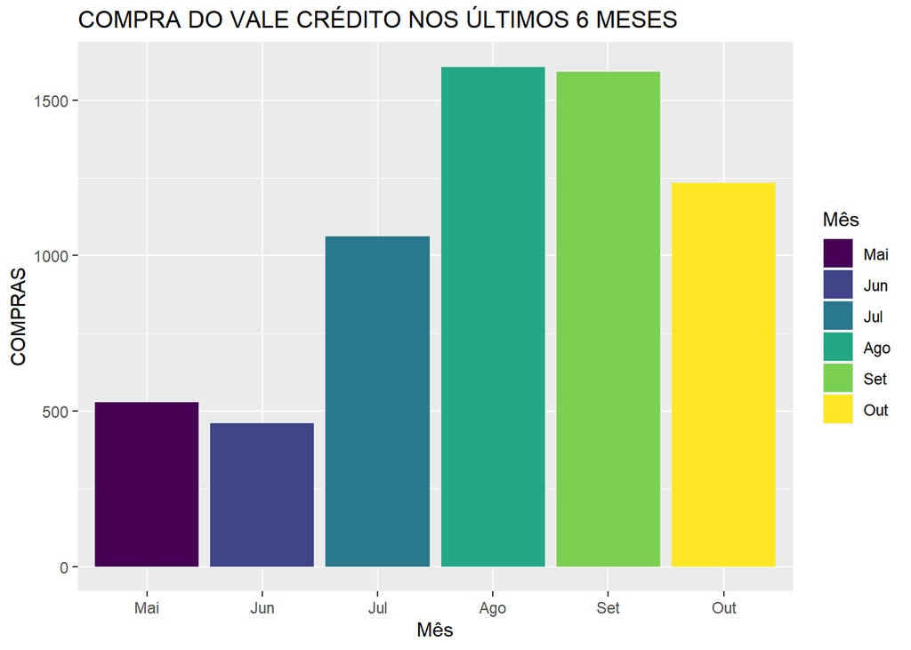

```r
dados2 = select(tabela2, DATA_DA_MOVIMENTACAO, TIPO_TRANSACAO_VC)

#seleção dos meses

#maio
maio2020 = as.data.frame(table(filter(dados2, DATA_DA_MOVIMENTACAO >= "2020-05-01" & DATA_DA_MOVIMENTACAO <= "2020-05-31" & TIPO_TRANSACAO_VC == "CREDITO_GERADO_POR_COMPRA_DE_VC")))
mai20 = sum(maio2020$Freq)

#junho
junho2020 = as.data.frame(table(filter(dados2, DATA_DA_MOVIMENTACAO >= "2020-06-01" & DATA_DA_MOVIMENTACAO <= "2020-06-30" & TIPO_TRANSACAO_VC == "CREDITO_GERADO_POR_COMPRA_DE_VC")))
jun20 = sum(junho2020$Freq)

#julho
julho2020 = as.data.frame(table(filter(dados2, DATA_DA_MOVIMENTACAO >= "2020-07-01" & DATA_DA_MOVIMENTACAO <= "2020-07-31" & TIPO_TRANSACAO_VC == "CREDITO_GERADO_POR_COMPRA_DE_VC")))
jul20 = sum(julho2020$Freq)

#agosto
agosto2020 = as.data.frame(table(filter(dados2, DATA_DA_MOVIMENTACAO >= "2020-08-01" & DATA_DA_MOVIMENTACAO <= "2020-08-31" & TIPO_TRANSACAO_VC == "CREDITO_GERADO_POR_COMPRA_DE_VC")))
ago20 = sum(agosto2020$Freq)

#setembro
setembro2020 = as.data.frame(table(filter(dados2, DATA_DA_MOVIMENTACAO >= "2020-09-01" & DATA_DA_MOVIMENTACAO <= "2020-09-30" & TIPO_TRANSACAO_VC == "CREDITO_GERADO_POR_COMPRA_DE_VC")))
set20 = sum(setembro2020$Freq)

#outubro
outubro2020 = as.data.frame(table(filter(dados2, DATA_DA_MOVIMENTACAO >= "2020-10-01" & DATA_DA_MOVIMENTACAO <= "2020-10-31" & TIPO_TRANSACAO_VC == "CREDITO_GERADO_POR_COMPRA_DE_VC")))
out20 = sum(outubro2020$Freq)

#Data base para construção do gráfico
v3_meses = c(mai20, jun20, jul20, ago20, set20, out20)
v3_nomes = c("Mai", "Jun", "Jul", "Ago", "Set", "Out")

v3_meses = as.data.frame(v3_meses)
v3_meses = cbind(v3_meses, v3_nomes)

colnames(v3_meses)[1] = "COMPRAS"
colnames(v3_meses)[2] = "Mês"

#Construção do gráfico de barras
library(ggplot2)

v3_meses$Mês = factor(v3_meses$Mês, levels = v3_meses$Mês, ordered= T)

ggplot(v3_meses, aes(x = Mês, y = COMPRAS, fill = Mês)) +
  geom_col() +
  labs(title = "COMPRA DO VALE CRÉDITO NOS ÚLTIMOS 6 MESES")
```

Pelo gráfico podemos perceber uma baixa demanda nos meses de **Maio** e **Junho**, começando uma recuperação no mês de **Julho**. Uma provável justificativa deste cenário é a Pandemia do COVID-19 que no primeiro semestre de 2020 provou restrições mais sérias ao comércio em geral.

Tais restrições foram flexibilizadas no segundo semestre de 2020, justificando, assim, uma recuperação do crescimento a partir do mês de **julho**.

Espero conseguir fazer parte da equipe de Data Analytics da Bemol Digital para cada vez mais me capacitar na área e contribuir com o desenvolvimento do trabalho da equipe.

Mais uma vez, agradeço pela oportunidade !

Matheus Bastos.